# PPMI-PEG mQTL / metQTL Overlap Analysis

Longitudinal mQTL meta-hits overlapped with PEG1 metabolomics QTLs, annotated via Ensembl

November 15, 2026

## Overview

This report combines three analysis stages:

1. **metQTL FDR handling and overlap** — combining PEG1 c18 + hilic trans-metQTL results, and overlapping FDR-significant SNP-metabolite pairs against the classified longitudinal PPMI mQTL results (from the meta-analysis hit list, re-tested with a mixed model across follow-up visits).
2. **Gene annotation** — resolving the overlapping SNPs to nearest/overlapping genes via the Ensembl REST API, since a shared SNP driving both a methylation and a metabolite association is the strongest signal of a pleiotropic locus worth following up.
3. **PD GWAS overlap and union table** — checking whether the case meta-analysis mQTL hits fall near a known PD risk locus from Nalls et al. (2019, Table S2), then building a union table of case hits supported by *either* the metQTL overlap *or* GWAS proximity (or both).

Metabolite features (`C18_mz_rt_...` / `HILIC_mz_rt_...`) are reported under their original mass-spec feature labels; they are **not** annotated to compounds. No collaborator compound-ID mapping exists. An earlier ad-hoc xmsannotator annotation (2026-07) covered the overlap from the pre-fix PEG results (genotype/sample misalignment and REF-allele coding, fixed 2026-11-11/12), was not reproducible from this repo, and covered only 4 of the current overlap features, so it was dropped on 2026-11-15 (archived in `archive/pre_pegfix_20261114/`). Compound annotation, if needed, should be redone on the current overlap with a script kept in this repo.

**A methodological note carried through this analysis:** the `trans_metqtls.txt.gz` files are generated with a liberal `pvOutputThreshold` (1e-2, set in `pipelines/PEG_METAB/config.yaml`) so that enough candidate SNPs survive to make the overlap with the longitudinal mQTL hits informative. The complete output is written gzipped and kept intact; the truncation to the first 1e+06 rows now happens **at read time** here, by streaming the gzip and stopping at the cap, rather than by a manual `head` on the cluster before transfer.

Two consequences follow, and both matter:

- The rows we load are *not* the full test space, so a BH correction recomputed on them alone would be invalid — it would rank an already-preselected low-p subset against itself instead of against the true, much larger, denominator of all tests performed. We therefore use **MatrixEQTL’s own per-file FDR column**, which is computed against that true denominator before any truncation, rather than recomputing it here. This requires `noFDRsaveMemory = FALSE` in `run_metqtl.R`; with it on, MatrixEQTL omits the FDR column entirely.
- The cap is only safe because MatrixEQTL sorts its output by p-value ascending when it computes FDR. Truncating therefore discards the least significant tail, not an arbitrary slice.

c18 and hilic are treated as separate multiple-testing families rather than one merged correction, since a combined correction isn’t recoverable from truncated data anyway.

## Step 1: Combine metQTL results and apply FDR filtering

```r
combine_and_fdr <- function(group_label, files, fdr_threshold = 0.05) {

  combined <- bind_rows(lapply(files, function(f) {
    # read_tsv streams the gzip rather than expanding it, and n_max stops the
    # read at the cap, so peak memory is bounded by the cap and not by the
    # on-disk file — which at pval_trans = 1e-2 is several GB compressed.
    read_tsv(f, col_types = cols(SNP = col_character(), gene = col_character(),
                                  beta = col_double(), `t-stat` = col_double(),
                                  `p-value` = col_double(), FDR = col_double()),
              n_max = MAX_TRANS_ROWS, guess_max = Inf) %>%
      mutate(source_file = basename(dirname(f)))
  }))

  # Safety net for the row cap. Rows are p-value ascending, so significant rows
  # can only be lost if a file both hit the cap AND was still significant at the
  # last retained row. Anything else means the cap only cut dead tail.
  cap_check <- combined %>%
    group_by(source_file) %>%
    summarise(n = n(), worst_fdr = max(FDR, na.rm = TRUE), .groups = "drop") %>%
    mutate(hit_cap = n >= MAX_TRANS_ROWS,
           clipped_signal = hit_cap & worst_fdr < fdr_threshold)
  print(cap_check)
  if (any(cap_check$clipped_signal)) {
    cat(sprintf(paste0("\n  *** MAX_TRANS_ROWS (%s) CLIPPED SIGNIFICANT ROWS in: %s. ",
                       "The FDR<%.2f set is truncated — raise the cap and re-run. ***\n"),
                format(MAX_TRANS_ROWS, big.mark = ","),
                paste(cap_check$source_file[cap_check$clipped_signal], collapse = ", "),
                fdr_threshold))
  }

  sig <- combined %>% filter(FDR < fdr_threshold)

  # The combined table is the capped read in full and is never read back — only
  # `sig` feeds the overlap. write_csv gzips on a .gz extension, which takes it
  # from ~2.4 GB to a fraction of that per group. `sig` stays plain: it is small
  # and gets opened by hand.
  out_all <- file.path(RESULTS_DIR, sprintf("peg1_%s_metqtl_combined_fdr.csv.gz", group_label))
  out_sig <- file.path(RESULTS_DIR, sprintf("peg1_%s_metqtl_sig_fdr05.csv", group_label))
  write_csv(combined, out_all)
  write_csv(sig, out_sig)

  list(combined = combined, sig = sig)
}

cases_metqtl    <- combine_and_fdr(
  "cases",
  c("../../results/PEG_METAB/metqtl/c18_peg1_cases/trans_metqtls.txt.gz",
    "../../results/PEG_METAB/metqtl/hilic_peg1_cases/trans_metqtls.txt.gz")
)
```

```
## # A tibble: 2 × 5
##   source_file            n worst_fdr hit_cap clipped_signal
##   <chr>              <int>     <dbl> <lgl>   <lgl>
## 1 c18_peg1_cases   1000000     0.583 TRUE    FALSE
## 2 hilic_peg1_cases 1000000     0.636 TRUE    FALSE
```

```r
controls_metqtl <- combine_and_fdr(
  "controls",
  c("../../results/PEG_METAB/metqtl/c18_peg1_controls/trans_metqtls.txt.gz",
    "../../results/PEG_METAB/metqtl/hilic_peg1_controls/trans_metqtls.txt.gz")
)
```

```
## # A tibble: 2 × 5
##   source_file               n worst_fdr hit_cap clipped_signal
##   <chr>                 <int>     <dbl> <lgl>   <lgl>
## 1 c18_peg1_controls   1000000     0.575 TRUE    FALSE
## 2 hilic_peg1_controls 1000000     0.545 TRUE    FALSE
```

```r
metqtl_cases_sig    <- cases_metqtl$sig
metqtl_controls_sig <- controls_metqtl$sig
```

```r
metqtl_summary <- tibble(
  group           = c("Cases", "Controls"),
  total_tests     = c(nrow(cases_metqtl$combined), nrow(controls_metqtl$combined)),
  fdr_sig_pairs   = c(nrow(metqtl_cases_sig), nrow(metqtl_controls_sig))
)
kable(metqtl_summary, caption = "PEG1 metQTL: total tests combined (c18+hilic) and FDR<0.05 pairs")
```

PEG1 metQTL: total tests combined (c18+hilic) and FDR<0.05 pairs

| group | total_tests | fdr_sig_pairs |
| --- | --- | --- |
| Cases | 2e+06 | 11327 |
| Controls | 2e+06 | 18022 |

## Step 2: Overlap with classified longitudinal mQTL results

Overlap is defined by shared SNP identity, cases-vs-cases and controls-vs-controls kept separate (different populations, not directly comparable). A single pleiotropic SNP can legitimately show up with multiple significant CpGs *and* multiple significant metabolites — that many-to-many structure is expected biology, not a join error.

```r
overlap_group <- function(group_label, mqtl_classified_file, metqtl_sig) {

  mqtl <- read_csv(mqtl_classified_file,
                    col_types = cols(pair_id = col_character(), snp_id = col_character(),
                                      cpg_id = col_character(), status = col_character(),
                                      warnings = col_character(), category = col_character(),
                                      same_sign_as_meta = col_logical(), replicated = col_logical(),
                                      dynamic = col_logical(), .default = col_double()),
                    guess_max = Inf)

  overlap <- mqtl %>%
    inner_join(metqtl_sig, by = c("snp_id" = "SNP"), relationship = "many-to-many") %>%
    rename(metabolite_feature = gene, metqtl_beta = beta, metqtl_pval = `p-value`, metqtl_fdr = FDR)

  write_csv(overlap, file.path(RESULTS_DIR, sprintf("mqtl_metqtl_overlap_%s.csv", group_label)))

  # Carry the mQTL denominator with the result so the summary table can report
  # it instead of a hardcoded literal that goes stale on the next re-run.
  attr(overlap, "n_mqtl_pairs") <- nrow(mqtl)
  overlap
}

overlap_cases <- overlap_group("cases",
  "../../results/PPMI_LONG/longitudinal_mqtl_cases_classified.csv", metqtl_cases_sig)

overlap_controls <- overlap_group("controls",
  "../../results/PPMI_LONG/longitudinal_mqtl_controls_classified.csv", metqtl_controls_sig)
```

```r
overlap_summary <- tibble(
  group                = c("Cases", "Controls"),
  # Derived, not hardcoded: these were literals (18986, 15282) from a run two
  # hit-lists ago and silently misreported the denominator once PPMI_LONG was
  # re-run against a new meta-analysis.
  mqtl_pairs_tested     = c(attr(overlap_cases, "n_mqtl_pairs"),
                            attr(overlap_controls, "n_mqtl_pairs")),
  metqtl_sig_pairs       = c(nrow(metqtl_cases_sig), nrow(metqtl_controls_sig)),
  unique_shared_snps     = c(n_distinct(overlap_cases$snp_id), n_distinct(overlap_controls$snp_id)),
  overlap_rows           = c(nrow(overlap_cases), nrow(overlap_controls))
)
kable(overlap_summary, caption = "mQTL x metQTL overlap summary")
```

mQTL x metQTL overlap summary

| group | mqtl_pairs_tested | metqtl_sig_pairs | unique_shared_snps | overlap_rows |
| --- | --- | --- | --- | --- |
| Cases | 26476 | 11327 | 46 | 69 |
| Controls | 14056 | 18022 | 37 | 50 |

### Longitudinal category breakdown among overlapping SNPs

```r
cat_cases <- overlap_cases %>% distinct(snp_id, category) %>% count(category) %>% mutate(group = "Cases")
cat_controls <- overlap_controls %>% distinct(snp_id, category) %>% count(category) %>% mutate(group = "Controls")
bind_rows(cat_cases, cat_controls) %>%
  pivot_wider(names_from = group, values_from = n, values_fill = 0) %>%
  kable(caption = "Longitudinal classification of SNPs shared with metQTL hits")
```

Longitudinal classification of SNPs shared with metQTL hits

| category | Cases | Controls |
| --- | --- | --- |
| replicated_static | 46 | 37 |

### Dynamic mQTLs (cases): metQTL overlap status

The overlap above is an *inner join* — it only shows hits that overlapped a metQTL, so a longitudinally “dynamic” mQTL with no metabolite signal would be invisible by construction. To see all dynamic hits regardless of metQTL status, we take the classified longitudinal results (cases) as the **left** table and left-join the metQTL significant set, keeping every dynamic hit whether or not it matched.

```r
cases_classified_full <- read_csv("../../results/PPMI_LONG/longitudinal_mqtl_cases_classified.csv",
                                   col_types = cols(pair_id = col_character(), snp_id = col_character(),
                                                     cpg_id = col_character(), status = col_character(),
                                                     warnings = col_character(), category = col_character(),
                                                     same_sign_as_meta = col_logical(), replicated = col_logical(),
                                                     dynamic = col_logical(), .default = col_double()),
                                   guess_max = Inf)

dynamic_hits <- cases_classified_full %>%
  filter(category == "replicated_and_dynamic") %>%
  left_join(metqtl_cases_sig %>% select(SNP, gene, `p-value`, FDR),
            by = c("snp_id" = "SNP"), relationship = "many-to-many") %>%
  rename(metabolite_feature = gene, metqtl_pval = `p-value`, metqtl_fdr = FDR) %>%
  mutate(has_metqtl_match = !is.na(metabolite_feature))

kable(dynamic_hits %>%
        select(snp_id, cpg_id, main_beta, main_fdr, interaction_p, interaction_fdr,
               has_metqtl_match, metabolite_feature, metqtl_fdr),
      caption = "All 'replicated_and_dynamic' case mQTLs, with metQTL match status (left join — unmatched rows show NA)")
```

All ‘replicated_and_dynamic’ case mQTLs, with metQTL match status (left join — unmatched rows show NA)

| snp_id | cpg_id | main_beta | main_fdr | interaction_p | interaction_fdr | has_metqtl_match | metabolite_feature | metqtl_fdr |
| --- | --- | --- | --- | --- | --- | --- | --- | --- |
| 6:170532873 | cg25738786 | 0.2344038 | 0e+00 | 5.0e-06 | 0.0190784 | FALSE | NA | NA |
| 12:4940665 | cg19870512 | 0.1029869 | 0e+00 | 3.0e-06 | 0.0161404 | FALSE | NA | NA |
| 12:4937575 | cg26858704 | 0.0562915 | 0e+00 | 1.0e-07 | 0.0026704 | FALSE | NA | NA |
| 17:29149298 | cg17105886 | 0.0459637 | 0e+00 | 8.0e-07 | 0.0068467 | FALSE | NA | NA |
| 7:98258736 | cg21661022 | 0.1552412 | 0e+00 | 6.0e-07 | 0.0068467 | FALSE | NA | NA |
| 12:62766056 | cg05837036 | -0.0840151 | 0e+00 | 4.8e-06 | 0.0190784 | FALSE | NA | NA |
| 15:86146645 | cg13263323 | -0.0660977 | 1e-07 | 8.2e-06 | 0.0272366 | FALSE | NA | NA |

```r
no_metqtl <- dynamic_hits %>% filter(!has_metqtl_match)
cat("Dynamic mQTLs (cases) with NO metQTL overlap:", n_distinct(no_metqtl$snp_id), "\n")
```

```
## Dynamic mQTLs (cases) with NO metQTL overlap: 7
```

```r
kable(no_metqtl %>% select(snp_id, cpg_id, main_beta, main_fdr, interaction_p, interaction_fdr),
      caption = "Dynamic mQTLs (cases) with no corresponding metabolite QTL signal")
```

Dynamic mQTLs (cases) with no corresponding metabolite QTL signal

| snp_id | cpg_id | main_beta | main_fdr | interaction_p | interaction_fdr |
| --- | --- | --- | --- | --- | --- |
| 6:170532873 | cg25738786 | 0.2344038 | 0e+00 | 5.0e-06 | 0.0190784 |
| 12:4940665 | cg19870512 | 0.1029869 | 0e+00 | 3.0e-06 | 0.0161404 |
| 12:4937575 | cg26858704 | 0.0562915 | 0e+00 | 1.0e-07 | 0.0026704 |
| 17:29149298 | cg17105886 | 0.0459637 | 0e+00 | 8.0e-07 | 0.0068467 |
| 7:98258736 | cg21661022 | 0.1552412 | 0e+00 | 6.0e-07 | 0.0068467 |
| 12:62766056 | cg05837036 | -0.0840151 | 0e+00 | 4.8e-06 | 0.0190784 |
| 15:86146645 | cg13263323 | -0.0660977 | 1e-07 | 8.2e-06 | 0.0272366 |

## Step 3: Gene annotation via Ensembl REST API

```r
unique_snps <- union(overlap_cases$snp_id, overlap_controls$snp_id)

WINDOW <- 250000
BASE_URL <- "https://rest.ensembl.org"

annotate_snp <- function(snp_id) {
  parts <- strsplit(snp_id, ":")[[1]]
  chr <- parts[1]
  pos <- as.integer(parts[2])

  query_region <- function(start, end) {
    url <- sprintf("%s/overlap/region/human/%s:%d-%d?feature=gene;content-type=application/json",
                    BASE_URL, chr, start, end)
    resp <- tryCatch(GET(url), error = function(e) NULL)
    if (is.null(resp) || status_code(resp) != 200) return(NULL)
    fromJSON(content(resp, as = "text", encoding = "UTF-8"), flatten = TRUE)
  }

  hit <- query_region(pos, pos)
  Sys.sleep(0.1)

  if (!is.null(hit) && length(hit) > 0 && is.data.frame(hit) && nrow(hit) > 0) {
    gene_labels <- ifelse(is.na(hit$external_name) | hit$external_name == "",
                           hit$id, hit$external_name)
    genes <- unique(gene_labels)
    return(tibble(snp_id = snp_id, gene = paste(genes, collapse = ";"),
                   relationship = "overlapping", distance_bp = 0))
  }

  hit_wide <- query_region(max(1, pos - WINDOW), pos + WINDOW)
  Sys.sleep(0.1)

  if (is.null(hit_wide) || length(hit_wide) == 0 || !is.data.frame(hit_wide) || nrow(hit_wide) == 0) {
    return(tibble(snp_id = snp_id, gene = NA_character_,
                   relationship = paste0("none_within_", WINDOW, "bp"), distance_bp = NA_integer_))
  }

  hit_wide <- hit_wide %>%
    mutate(dist = pmax(0, pmax(start - pos, pos - end)),
           gene_label = ifelse(is.na(external_name) | external_name == "", id, external_name))

  nearest <- hit_wide %>% slice_min(dist, n = 1, with_ties = FALSE)

  tibble(snp_id = snp_id, gene = nearest$gene_label,
         relationship = "nearest", distance_bp = nearest$dist)
}

annotations <- map_dfr(unique_snps, function(s) {
  tryCatch(annotate_snp(s), error = function(e) {
    tibble(snp_id = s, gene = NA_character_, relationship = "query_failed", distance_bp = NA_integer_)
  })
})

write_csv(annotations, file.path(RESULTS_DIR, "overlap_snp_gene_annotations.csv"))

overlap_cases_annot <- overlap_cases %>%
  left_join(annotations, by = "snp_id") %>%
  rename(nearest_gene = gene, gene_relationship = relationship, gene_distance_bp = distance_bp)

overlap_controls_annot <- overlap_controls %>%
  left_join(annotations, by = "snp_id") %>%
  rename(nearest_gene = gene, gene_relationship = relationship, gene_distance_bp = distance_bp)

write_csv(overlap_cases_annot, file.path(RESULTS_DIR, "mqtl_metqtl_overlap_cases_annotated.csv"))
write_csv(overlap_controls_annot, file.path(RESULTS_DIR, "mqtl_metqtl_overlap_controls_annotated.csv"))
```

### Annotation outcome

```r
kable(as.data.frame(table(relationship = annotations$relationship)),
      caption = "SNP -> gene annotation outcome (overlapping gene body, nearest within 250kb, or none found)")
```

SNP -> gene annotation outcome (overlapping gene body, nearest within 250kb, or none found)

| relationship | Freq |
| --- | --- |
| nearest | 23 |
| none_within_250000bp | 11 |
| overlapping | 48 |

### Genes implicated, cases

```r
genes_cases <- overlap_cases_annot %>%
  distinct(snp_id, nearest_gene) %>%
  filter(!is.na(nearest_gene), nearest_gene != "") %>%
  count(nearest_gene, sort = TRUE)

kable(genes_cases, caption = "Unique genes implicated by shared SNPs — Cases")
```

Unique genes implicated by shared SNPs — Cases

| nearest_gene | n |
| --- | --- |
| ENSG00000286192;MAD1L1 | 3 |
| ERLIN1 | 3 |
| MECR | 3 |
| TRPM4 | 3 |
| LINC01150;ENSG00000304754;PRR33 | 2 |
| SCAPER | 2 |
| ACACA | 1 |
| AP4M1 | 1 |
| ARHGEF17 | 1 |
| BRI3BP | 1 |
| C4B | 1 |
| DBR1 | 1 |
| EFCAB6-AS1 | 1 |
| ENSG00000286387 | 1 |
| ENSG00000293588 | 1 |
| ENSG00000297365 | 1 |
| ENSG00000297851 | 1 |
| ENSG00000299899 | 1 |
| ENSG00000304504 | 1 |
| ENSG00000304656;RASA3 | 1 |
| GRM7-AS3;GRM7 | 1 |
| HCG22 | 1 |
| HRG-AS1;KNG1 | 1 |
| MAP2K1P1 | 1 |
| MYT1L | 1 |
| RPL3L | 1 |
| SNX8 | 1 |
| SPCS2P2 | 1 |
| SYT4 | 1 |
| SYT7 | 1 |
| TANK-AS1 | 1 |
| UBE2J2 | 1 |

### Genes implicated, controls

```r
genes_controls <- overlap_controls_annot %>%
  distinct(snp_id, nearest_gene) %>%
  filter(!is.na(nearest_gene), nearest_gene != "") %>%
  count(nearest_gene, sort = TRUE)

kable(genes_controls, caption = "Unique genes implicated by shared SNPs — Controls")
```

Unique genes implicated by shared SNPs — Controls

| nearest_gene | n |
| --- | --- |
| ENSG00000296651 | 2 |
| SCAND3 | 2 |
| BISPR;ENSG00000269481;ENSG00000254503;MVB12A | 1 |
| BST2 | 1 |
| CD59 | 1 |
| COX11P1 | 1 |
| EEF1DP6 | 1 |
| ENSG00000225610;INO80D | 1 |
| ENSG00000273712;ENSG00000294464;ZSCAN31 | 1 |
| ENSG00000294464;ZSCAN31 | 1 |
| ENSG00000300257 | 1 |
| ENSG00000303050;FOXP2 | 1 |
| ENSG00000306674;ZNF777 | 1 |
| ENSG00000307801;EPM2A | 1 |
| EPDR1;SFRP4 | 1 |
| ERLIN1 | 1 |
| KCNAB2 | 1 |
| KCNB2 | 1 |
| PTPRN2 | 1 |
| RBM38 | 1 |
| RN7SL44P | 1 |
| RNASE10 | 1 |
| SENP7 | 1 |
| SNX19 | 1 |
| TSBP1-AS1 | 1 |
| ZKSCAN8P2 | 1 |

### Gene frequency, top hits

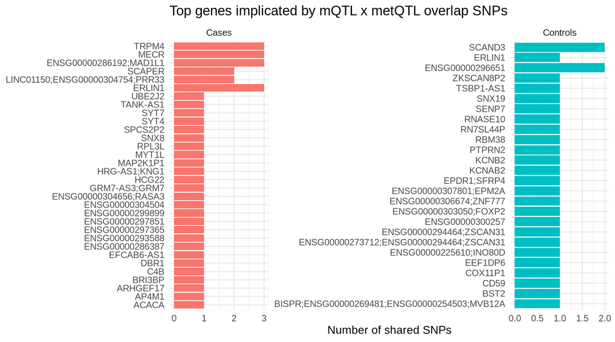

```r
top_genes <- bind_rows(
  genes_cases %>% mutate(group = "Cases"),
  genes_controls %>% mutate(group = "Controls")
) %>%
  group_by(group) %>%
  slice_max(n, n = 10) %>%
  ungroup()

ggplot(top_genes, aes(x = reorder(nearest_gene, n), y = n, fill = group)) +
  geom_col(show.legend = FALSE) +
  coord_flip() +
  facet_wrap(~group, scales = "free") +
  labs(x = NULL, y = "Number of shared SNPs",
       title = "Top genes implicated by mQTL x metQTL overlap SNPs") +
  theme_minimal(base_size = 12)
```

## Step 4: Overlap with Nalls et al. PD GWAS loci

Using the curated Nalls et al. (2019) locus table (Table S2) — already restricted to genome-wide significant, LD-independent lead SNPs — rather than the looser nominal-significance (p<0.05) SNP list, since the latter would flag a large fraction of any SNP set as a “GWAS hit” by chance alone.

Because these are independent lead SNPs from a clumping procedure, they are unlikely to be the exact variant present in the PPMI/PEG genotype panel. We therefore use a **window-based match (±250kb)** rather than requiring identical `chr:pos` — the same logic used for the Ensembl gene-annotation step above. This window is a judgment call; tighten or loosen `GWAS_WINDOW` below as appropriate.

```r
GWAS_WINDOW <- 250000   # bp; matches the Ensembl gene-annotation window

nalls_raw <- read_tsv("../../Downloads/reference/Nalls_GWAS/PDNallsP005_TableS2.csv",
                       col_types = cols(.default = col_character()), guess_max = Inf)

qtl_gene_col   <- grep("QTL_Nominated_Gene", names(nalls_raw), value = TRUE)[1]
p_all_col      <- grep("^P_all_studies$", names(nalls_raw), value = TRUE)[1]
locus_num_col  <- grep("Locus_Number", names(nalls_raw), value = TRUE)[1]

nalls <- nalls_raw %>%
  transmute(
    nalls_snp     = SNP,
    CHR           = as.integer(CHR),
    BP            = as.integer(gsub(",", "", BP)),
    nearest_gene  = Nearest_Gene,
    qtl_gene      = .data[[qtl_gene_col]],
    p_all_studies = as.numeric(.data[[p_all_col]]),
    locus_number  = as.integer(.data[[locus_num_col]])
  )

stopifnot("Nalls BP parsing failed" = sum(is.na(nalls$BP)) == 0)
stopifnot("Nalls CHR parsing failed" = sum(is.na(nalls$CHR)) == 0)

cat("Nalls loci loaded:", nrow(nalls), "\n")
```

```
## Nalls loci loaded: 90
```

```r
cases_meta <- read_csv("../../results/PPMI_LONG/longitudinal_mqtl_cases_classified.csv",
                        col_types = cols(pair_id = col_character(), snp_id = col_character(),
                                          cpg_id = col_character(), status = col_character(),
                                          warnings = col_character(), category = col_character(),
                                          same_sign_as_meta = col_logical(), replicated = col_logical(),
                                          dynamic = col_logical(), .default = col_double()),
                        guess_max = Inf)

case_snps <- cases_meta %>%
  distinct(snp_id) %>%
  mutate(chr = str_extract(snp_id, "^[^:]+"),
         pos = as.integer(str_extract(snp_id, "(?<=:)[0-9]+")))

match_gwas <- function(chr, pos) {
  cand <- nalls %>% filter(as.character(CHR) == chr)
  if (nrow(cand) == 0) {
    return(tibble(is_gwas_hit = FALSE, gwas_dist_bp = NA_integer_,
                   gwas_nearest_gene = NA_character_, gwas_locus_number = NA_integer_))
  }
  dists <- abs(cand$BP - pos)
  i <- which.min(dists)
  tibble(is_gwas_hit = dists[i] <= GWAS_WINDOW, gwas_dist_bp = dists[i],
         gwas_nearest_gene = cand$nearest_gene[i], gwas_locus_number = cand$locus_number[i])
}

gwas_matches <- case_snps %>%
  mutate(m = pmap(list(chr, pos), match_gwas)) %>%
  unnest(m)

cat("Unique case-hit SNPs tested against Nalls loci:", nrow(gwas_matches), "\n")
```

```
## Unique case-hit SNPs tested against Nalls loci: 21176
```

```r
cat("Within", GWAS_WINDOW/1000, "kb of a known PD GWAS locus:", sum(gwas_matches$is_gwas_hit), "\n")
```

```
## Within 250 kb of a known PD GWAS locus: 651
```

### GWAS-adjacent case hits

```r
gwas_hits_table <- gwas_matches %>%
  filter(is_gwas_hit) %>%
  arrange(gwas_dist_bp) %>%
  select(snp_id, gwas_nearest_gene, gwas_locus_number, gwas_dist_bp)

kable(gwas_hits_table, caption = "Case mQTL SNPs within 250kb of a known Nalls et al. PD GWAS locus")
```

Case mQTL SNPs within 250kb of a known Nalls et al. PD GWAS locus

| snp_id | gwas_nearest_gene | gwas_locus_number | gwas_dist_bp |
| --- | --- | --- | --- |
| 1:205723572 | NUCKS1 | 4 | 0 |
| 9:17579690 | SH3GL2 | 41 | 0 |
| 8:22525980 | BIN3 | 39 | 0 |
| 6:32578653 | HLA-DRB5 | 31 | 119 |
| 17:42294462 | UBTF | 68 | 125 |
| 6:30108111 | TRIM40 | 30 | 572 |
| 11:133787717 | IGSF9B | 48 | 716 |
| 14:55347827 | GCH1 | 56 | 1042 |
| 19:2339975 | SPPL2B | 76 | 1072 |
| 16:50737980 | NOD2 | 63 | 1324 |
| 12:123328378 | HIP1R | 51 | 1780 |
| 1:226917898 | ITPKB | 5 | 1820 |
| 4:954247 | TMEM175 | 19 | 2300 |
| 17:76423097 | DNAH17 | 72 | 2383 |
| 11:133784410 | IGSF9B | 48 | 2591 |
| 16:50739450 | NOD2 | 63 | 2794 |
| 6:30111487 | TRIM40 | 30 | 2804 |
| 17:7358520 | CHRNB1 | 66 | 2899 |
| 1:161465420 | FCGR2A | 2 | 3634 |
| 1:226912196 | ITPKB | 5 | 3882 |
| 4:956047 | TMEM175 | 19 | 4100 |
| 14:88468510 | GALC | 58 | 4246 |
| 6:27734470 | LOC100131289 | 29 | 4331 |
| 19:2336527 | SPPL2B | 76 | 4520 |
| 6:30103923 | TRIM40 | 30 | 4760 |
| 6:30103898 | TRIM40 | 30 | 4785 |
| 17:42299300 | UBTF | 68 | 4963 |
| 6:30103360 | TRIM40 | 30 | 5323 |
| 6:30103049 | TRIM40 | 30 | 5634 |
| 11:133792644 | IGSF9B | 48 | 5643 |

[output cut: 621 more lines]